**AI for Mechanical Engineering**  
**Recurrent Neural Networks (RNN)**

# Problem 1: LSTM with TensorFlow

- In this problem, you will make a LSTM model to predict the half of an MNIST image using the other half.
- You will split an MNIST image into 28 pieces.
- MNIST is 28 x 28 image. The model predicts a piece of 1 x 28 image.
- First, 14 x 28 image will be feeded into a model as time series, then the model predict the last 14 x 28 image, recursively.

```python
import tensorflow as tf
import numpy as np
import matplotlib.pyplot as plt
```

1. Load MNIST Data
- Download MNIST data from the tensorflow tutorial example

```python
(train_imgs, train_labels), (test_imgs, test_labels) = tf.keras.datasets.mnist.load_data()

train_imgs = train_imgs/255.0
test_imgs = test_imgs/255.0

print('train_x: ', train_imgs.shape)
print('test_x: ', test_imgs.shape)
```

```
Downloading data from https://storage.googleapis.com/tensorflow/tf-keras-datasets/mnist.npz
train_x:  (60000, 28, 28)
test_x:  (10000, 28, 28)
```

2. Plot a ramdomly selected data with its label

```python
def batchmaker(x, y, n_batch):
    idx = np.random.randint(len(x), size = n_batch)
    return x[idx], y[idx]
```

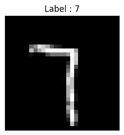

```python
train_x, train_y = batchmaker(train_imgs, train_labels, 1)
img = train_x[0].reshape(28, 28)

plt.figure(figsize = (5, 3))
plt.imshow(img,'gray')
plt.title("Label : {}".format(train_y[0]))
plt.xticks([])
plt.yticks([])
plt.show()
```

3. Define LSTM Structure

```python
## write your code here
#
```

4. Define Cost, Initializer and Optimizer Loss
- Regression: Squared loss

$$ \frac{1}{N} \sum_{i=1}^{N} (\hat{y}^{(i)} - y^{(i)})^2$$

- Initializer
  - Initialize all the empty variables
- Optimizer
  - AdamOptimizer: the most popular optimizer

```python
## write your code here
#
```

5. Define optimization configuration and then optimize
- Highly recommand to use GPU or Colab.

```python
## write your code here
#
```

6. Test or Evaluate
- Predict the MNIST image
- MNIST is 28 x 28 image. The model predicts a piece of 1 x 28 image.
- First, 14 x 28 image will be feeded into a model, then the model predict the last 14 x 28 image, recursively.

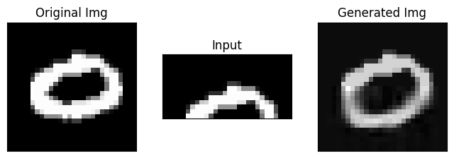

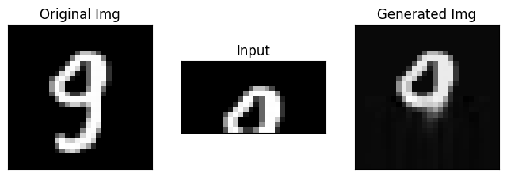

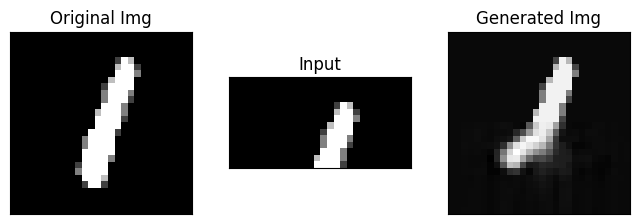

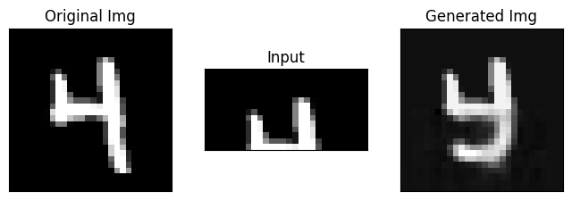

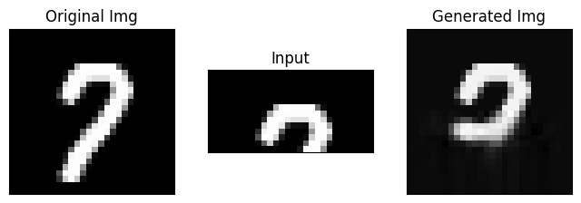

```python
## write your code here
#
```

# Problem 2

- In this problem, we have bearing data with 3 classes (healthy, inner fault, outer fault).
- The objective is to classify the given data using state-of-the-art deep learning models.
- You will build and test a deep learning model.

### Dataset Description

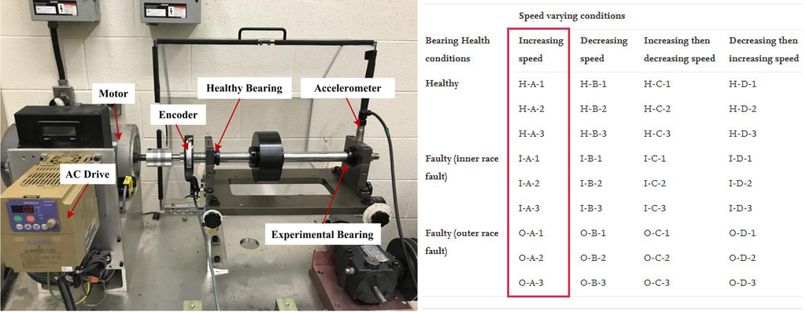

**Download & Load Data**

We already made the data ready for you. You can download the data in .npy format. Three files are prepared for a train set and three files for a test set.

- [Bearing_Healty_train.npy](https://drive.google.com/file/d/1WiIFy1QoIwY08W04XVYZLhuqIeWnYo2D/view?usp=sharing)
- [Bearing_InnerFault_train.npy](https://drive.google.com/file/d/1Mge0yUMlGivFRZpxh2DNjqIdYKg36-Ss/view?usp=sharing)
- [Bearing_OuterFault_train.npy](https://drive.google.com/file/d/19-8hdkCy8341yiQP5ZW6xLiIRNDceUko/view?usp=sharing)
- [Bearing_Healty_test.npy](https://drive.google.com/file/d/1N3Y4qS7kk_djZYuCOUdXjkepXsC9PFal/view?usp=sharing)
- [Bearing_InnerFault_test.npy](https://drive.google.com/file/d/1H9kktXrOlXnI5kazOb8ggqLjoRQDM48E/view?usp=sharing)
- [Bearing_OuterFault_test.npy](https://drive.google.com/file/d/1-D7gh0xKe26J1UDZcdmPS-oIQBdBbMyg/view?usp=sharing)

## Plot all data with the title of its filename.

```python
import tensorflow as tf
import numpy as np
import os
import matplotlib.pyplot as plt
%matplotlib inline
```

```python
from google.colab import drive
drive.mount('/content/drive')
```

```python
Healthy_train = np.load('/content/drive/MyDrive/DL_Colab/DL_data/Bearing_Healthy_train.npy')
InnerFault_train = np.load('/content/drive/MyDrive/DL_Colab/DL_data/Bearing_InnerFault_train.npy')
OuterFault_train = np.load('/content/drive/MyDrive/DL_Colab/DL_data/Bearing_OuterFault_train.npy')

Healthy_test = np.load('/content/drive/MyDrive/DL_Colab/DL_data/Bearing_Healthy_test.npy')
InnerFault_test = np.load('/content/drive/MyDrive/DL_Colab/DL_data/Bearing_InnerFault_test.npy')
OuterFault_test = np.load('/content/drive/MyDrive/DL_Colab/DL_data/Bearing_OuterFault_test.npy')
```

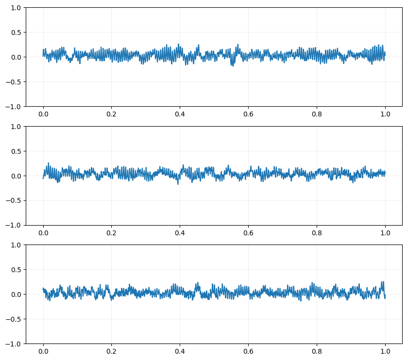

```python
## Your code here
#
```

In the following subproblems, you will be introduced deep learning models which are used for time-series data classification. You are asked to build the model with the given architecture and evaluate the performance.

### Various deep learning models for time-series data classification

In the deep learning field, there are plenty of models for time-series data classification. Compared to conventional machine learning algorithms, recent deep neural network models show much higher accuracy as you can see in the table below. In this problem, we will build the **CNN-LSTM model** which is one of the most successful, and whose elements are covered in this course.

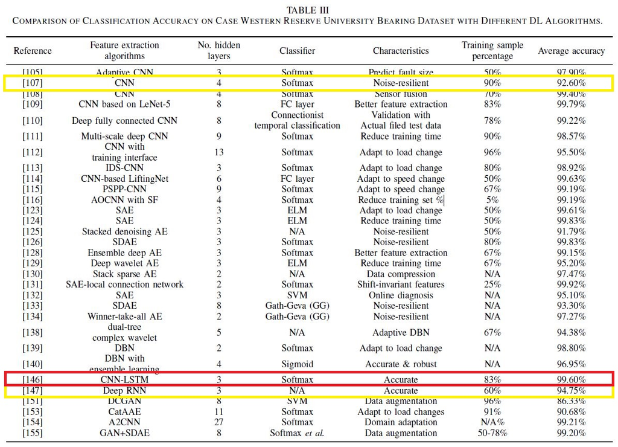

*"Deep Learning Algorithms for Bearing Fault Diagnostics – A Comprehensive Review", 2020, S Zhang et al.*

### Implementation of CNN-LSTM model

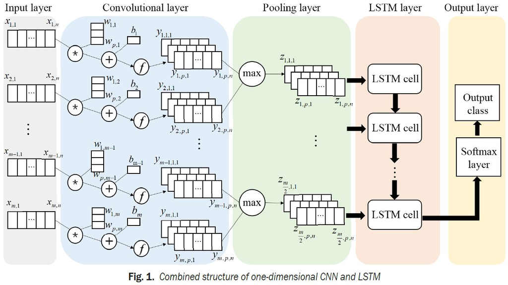

## Build the model based on the above information and print the structure.

Build the model based on the above information and print the structure. You can freely assign the other parameters that are not described in the above configuration in order to achieve better performance. (You don't need to refer the original paper for those.) Please refer to the summary of the model structure.

You will use the 1D convolution layer for this problem. We have learned 2D convolution in class and 1D convolution is nothing but 2D convolution with a height as 1.

**Input_shape of data = (4000, 2000, 1)**

2000 $\rightarrow$ 20 $\times$ 100 $\rightarrow$ CNN layers $\rightarrow$ LSTM layer

```python
## Your code here
#
```

```
Model: "sequential_1"
_________________________________________________________________
 Layer (type)                Output Shape              Param #
=================================================================
 reshape (Reshape)           (None, 20, 100)           0

 conv1d (Conv1D)             (None, 20, 32)            204832

 max_pooling1d (MaxPooling1  (None, 10, 32)            0
 D)

 lstm_2 (LSTM)               (None, 128)               82432

 dense_2 (Dense)             (None, 3)                 387

=================================================================
Total params: 287651 (1.10 MB)
Trainable params: 287651 (1.10 MB)
Non-trainable params: 0 (0.00 Byte)
_________________________________________________________________
```

## Create trainset and testset

Create trainset and testset to feed the model you designed. Set the number of segments equals to 4,000 for trainset and 1,000 for testset (for each class).

```python
## Your code here
#
```

## Train the model and print the training procedure.

```python
## Your code here
#
```

## Evaluate the model in terms of accuracy of the testset.

```python
## Your code here
#
```

```
[0.007681192364543676, 0.9990000128746033]
```

# Problem 3

- In this problem, we are going to predict sequence data using LSTM model
- You will build and test a deep learning model.

### Download & Load Data

We've already prepared the data. You can download [the data](https://www.dropbox.com/s/9x96u4tygd7iqty/data.txt?dl=1) in .txt format.

```python
import pandas as pd
import matplotlib.pyplot as plt
import numpy as np

from sklearn.preprocessing import MinMaxScaler
from sklearn.metrics import mean_squared_error

import keras
from keras.models import Sequential
from keras.layers import Dense, LSTM, Dropout
```

```python
df = pd.read_csv('./data.txt', sep=';',
                 parse_dates={'dt' : ['Date', 'Time']}, infer_datetime_format=True,
                 low_memory=False, na_values=['nan','?'], index_col='dt')

# filling nan with mean in any columns
for j in range(0,7):
    df.iloc[:,j]=df.iloc[:,j].fillna(df.iloc[:,j].mean())

df
```

```python
df_resample = df.resample('h').mean()
df_resample
```

In order to train the deep learning model using dataset, we are going to change the data type from dataframe to array.

```python
dataset = df_resample.values
print(dataset.shape)
```

## Data visualization

Plot all data with the title of its variable name.

```python
# Your code here
```

## Preprocessing

Each variables has different scale. Normalize the dataset.

```python
# Your code here
```

```python
print('min value:{:.1f}, max value:{:.1f}'.format(np.min(norm_dataset), np.max(norm_dataset)))
```

## Split dataset

(2.3.1) Referring to below image, create train and target data.

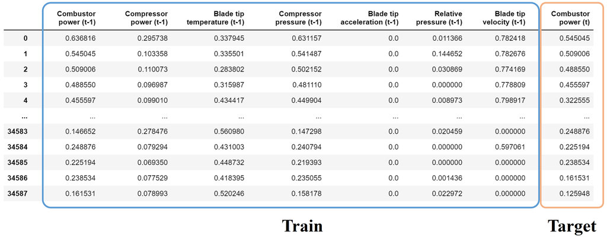

```python
# Your code here
```

(2.3.2) Set the trainset to 3 years and the testset to the remaining datasets.  
Hint: Since the data set is recorded hour by hour, 365*24 data are one-year data

```python
# Your code here
```

## Create model

```python
# Your code here
```

## Train the model

```python
# Your code here
```

## Plot the result

Predict your test dataset and compare the prediction value with target value.

```python
# Your code here
```